# Titanic

```python
# Importando os pacotes
import pandas as pd
import numpy as np
import plotly
import plotly.graph_objects as go
from plotly.subplots import make_subplots
```

```python
%%html
<style>
table {float:left}
</style>
```

```python
# Verscoes dos pacotes usados nesse notebook
%reload_ext watermark
%watermark --iversions
```

```
pandas     1.1.2
tensorflow 2.3.1
ipywidgets 7.5.1
numpy      1.18.1
json       2.0.9
plotly     4.12.0
```

O primeiro passo sera importar os datasets que foram baixados do kaggle e estao armazenados na pasta onde esta este notebook. Os dados podem ser baixados no seguinte link:

- https://www.kaggle.com/c/titanic/data

No site tambem encontramos a descricao das variaveis do dataset:

- `PassengerId:`
- `Survived:` variavel target
- `Pclass:` classe da passagem
- `Name:` Nome do passageiro
- `Sex:` Genero do passagero
- `Age:` idade do passageiro
- `SibSp:` Quantidade de parentes a bordo do navio
- `Parch:` Quantidade de pais ou filhos a bordo
- `Ticket:` Numero da passagem
- `Fare:`
- `Cabin:` Numero da cabine do passageiro
- `Embarked:` Porto onde o passageiro embarcou no navio

```python
#Importando os dados
dt_teste = pd.read_csv("test.csv")
dt_treino = pd.read_csv("train.csv")

dt_treino.head(5)
```

|  | PassengerId | Survived | Pclass | Name | Sex | Age | SibSp | Parch | Ticket | Fare | Cabin | Embarked |
| --- | --- | --- | --- | --- | --- | --- | --- | --- | --- | --- | --- | --- |
| 0 | 1 | 0 | 3 | Braund, Mr. Owen Harris | male | 22.0 | 1 | 0 | A/5 21171 | 7.2500 | NaN | S |
| 1 | 2 | 1 | 1 | Cumings, Mrs. John Bradley (Florence Briggs Th... | female | 38.0 | 1 | 0 | PC 17599 | 71.2833 | C85 | C |
| 2 | 3 | 1 | 3 | Heikkinen, Miss. Laina | female | 26.0 | 0 | 0 | STON/O2. 3101282 | 7.9250 | NaN | S |
| 3 | 4 | 1 | 1 | Futrelle, Mrs. Jacques Heath (Lily May Peel) | female | 35.0 | 1 | 0 | 113803 | 53.1000 | C123 | S |
| 4 | 5 | 0 | 3 | Allen, Mr. William Henry | male | 35.0 | 0 | 0 | 373450 | 8.0500 | NaN | S |

O primeiro passo antes de iniciarmos a parte de criacao do modelo será entendermos um pouco mais sobre os dados.

```python
dt_treino.dtypes
```

```
PassengerId      int64
Survived         int64
Pclass           int64
Name            object
Sex             object
Age            float64
SibSp            int64
Parch            int64
Ticket          object
Fare           float64
Cabin           object
Embarked        object
dtype: object
```

```python
dt_treino.describe()
```

|  | PassengerId | Survived | Pclass | Age | SibSp | Parch | Fare |
| --- | --- | --- | --- | --- | --- | --- | --- |
| count | 891.000000 | 891.000000 | 891.000000 | 714.000000 | 891.000000 | 891.000000 | 891.000000 |
| mean | 446.000000 | 0.383838 | 2.308642 | 29.699118 | 0.523008 | 0.381594 | 32.204208 |
| std | 257.353842 | 0.486592 | 0.836071 | 14.526497 | 1.102743 | 0.806057 | 49.693429 |
| min | 1.000000 | 0.000000 | 1.000000 | 0.420000 | 0.000000 | 0.000000 | 0.000000 |
| 25% | 223.500000 | 0.000000 | 2.000000 | 20.125000 | 0.000000 | 0.000000 | 7.910400 |
| 50% | 446.000000 | 0.000000 | 3.000000 | 28.000000 | 0.000000 | 0.000000 | 14.454200 |
| 75% | 668.500000 | 1.000000 | 3.000000 | 38.000000 | 1.000000 | 0.000000 | 31.000000 |
| max | 891.000000 | 1.000000 | 3.000000 | 80.000000 | 8.000000 | 6.000000 | 512.329200 |

```python
dt_treino.describe(include=[np.object])
```

|  | Name | Sex | Ticket | Cabin | Embarked |
| --- | --- | --- | --- | --- | --- |
| count | 891 | 891 | 891 | 204 | 889 |
| unique | 891 | 2 | 681 | 147 | 3 |
| top | Cardeza, Mr. Thomas Drake Martinez | male | 1601 | C23 C25 C27 | S |
| freq | 1 | 577 | 7 | 4 | 644 |

```python
# Verificando os valores missing
valores_missing = dt_treino.isnull().sum()

grafico1 = go.Figure()
grafico1.add_trace(go.Bar(x=valores_missing.keys().values,
                                  y=valores_missing.values,
                                  text=valores_missing.values,
                                  textposition='auto'))
grafico1.update_layout(title="Quantidade de Valores Missing", title_x=0.5)
grafico1.show()
```

[interactive chart not shown]

```python
sobreviventes = dt_treino['Survived'].value_counts().reset_index()
legenda = {0:'not survived', 1:'survived'}

sobreviventes['legenda'] = sobreviventes['index'].map(legenda)
sobreviventes.sort_values(['Survived'], ascending=False,inplace=True)

grafico1 = go.Figure()
grafico1.add_trace(go.Pie(labels=sobreviventes['legenda'], values=sobreviventes['Survived']))
grafico1.update_layout(title="Sobreviventes", title_x=0.5)
grafico1.show()
```

[interactive chart not shown]

## Analisando as variaveis categoricas

```python
def analisa_variavel(nome_variavel):
    # Gerando os dados para o grafico de pizza
    sexo = dt_treino[nome_variavel].value_counts()

    # Gerando os valores pro grafico de barras
    sexo_sobreviventes = pd.DataFrame(dt_treino['Survived'].groupby(dt_treino[nome_variavel]).value_counts().rename('qtd_pessoas')).reset_index()

    x = sexo_sobreviventes.loc[sexo_sobreviventes['Survived']==1, nome_variavel]
    y = sexo_sobreviventes.loc[sexo_sobreviventes['Survived']==1, 'qtd_pessoas']

    x2 = sexo_sobreviventes.loc[sexo_sobreviventes['Survived']==0, nome_variavel]
    y2 = sexo_sobreviventes.loc[sexo_sobreviventes['Survived']==0, 'qtd_pessoas']


    grafico2 = make_subplots(rows=1, cols=2, specs=[[{'type':'pie'}, {'type':'bar'}]], subplot_titles=['Distribuição', 'Sobreviventes'])
    grafico2.add_trace(go.Pie(labels=sexo.keys().values, values=sexo.values), 1, 1)
    grafico2.add_trace(go.Bar(name='Survived', x=x, y=y, marker_color='rgb(55, 83, 109)'), 1, 2)
    grafico2.add_trace(go.Bar(name='Dont Survived', x=x2, y=y2, marker_color='crimson'), 1, 2)
    grafico2.update_layout(barmode='stack', title="Variavel "+nome_variavel, title_x=0.5)
    grafico2.show()

    #sexo_sobreviventes['percent'] = sexo_sobreviventes.apply(lambda x: x['qtd_pessoas']/sexo_sobreviventes['qtd_pessoas'].groupby(sexo_sobreviventes['Sex']).sum())
    sexo_sobreviventes['percent'] = sexo_sobreviventes['qtd_pessoas'] / sexo_sobreviventes['qtd_pessoas'].groupby(sexo_sobreviventes[nome_variavel]).sum()[sexo_sobreviventes[nome_variavel]].values
    display(sexo_sobreviventes[sexo_sobreviventes['Survived'] == 1])
```

```python
analisa_variavel('Sex')
```

[interactive chart not shown]

|  | Sex | Survived | qtd_pessoas | percent |
| --- | --- | --- | --- | --- |
| 0 | female | 1 | 233 | 0.742038 |
| 3 | male | 1 | 109 | 0.188908 |

```python
analisa_variavel('Pclass')
```

[interactive chart not shown]

|  | Pclass | Survived | qtd_pessoas | percent |
| --- | --- | --- | --- | --- |
| 0 | 1 | 1 | 136 | 0.629630 |
| 3 | 2 | 1 | 87 | 0.472826 |
| 5 | 3 | 1 | 119 | 0.242363 |

```python
analisa_variavel('SibSp')
```

[interactive chart not shown]

|  | SibSp | Survived | qtd_pessoas | percent |
| --- | --- | --- | --- | --- |
| 1 | 0 | 1 | 210 | 0.345395 |
| 2 | 1 | 1 | 112 | 0.535885 |
| 5 | 2 | 1 | 13 | 0.464286 |
| 7 | 3 | 1 | 4 | 0.250000 |
| 9 | 4 | 1 | 3 | 0.166667 |

```python
analisa_variavel('Parch')
```

[interactive chart not shown]

|  | Parch | Survived | qtd_pessoas | percent |
| --- | --- | --- | --- | --- |
| 1 | 0 | 1 | 233 | 0.343658 |
| 2 | 1 | 1 | 65 | 0.550847 |
| 5 | 2 | 1 | 40 | 0.500000 |
| 6 | 3 | 1 | 3 | 0.600000 |
| 10 | 5 | 1 | 1 | 0.200000 |

```python
analisa_variavel('Embarked')
```

[interactive chart not shown]

|  | Embarked | Survived | qtd_pessoas | percent |
| --- | --- | --- | --- | --- |
| 0 | C | 1 | 93 | 0.553571 |
| 3 | Q | 1 | 30 | 0.389610 |
| 5 | S | 1 | 217 | 0.336957 |

## Pré Processamento dos Dados

Agora que já temos uma noção de como os dados estão distribuidos podemos fazer o tratamento das variaveis para depois construirmos o modelo

### PassengerId, Name, Cabin, Ticket

- As variáveis `PassengerId` e `Name` são variáveis que possuem todos os valores distintos, sendo assim, elas não são boas para aplicarmos no modelo.
- A variável `Ticket` possui **681** valores distintos, sendo que a base possui 891 registros, por conta disso essa variável tambem não é boa para o modelo.
- A variével `Cabin` possui 687 valores missing, então não é interessante fazer açgum tratamento para preencher esses valores missing.

Todas essas 4 variáveis serão removidas da base por causa dos motivos citados

```python
dt_treino.drop(columns=['PassengerId', 'Name', 'Cabin', 'Ticket'], inplace=True)
dt_teste.drop(columns=['PassengerId', 'Name', 'Cabin', 'Ticket'], inplace=True)
```

### Pclass, SibSp, Parch

Não faremos nenhum tipo de tratamento nessas variáveis

### Sex

Iremos transformar a variavel sex em numerico

```python
id_sexo = {'female': 0, 'male': 1}

dt_treino['Sex'] = dt_treino['Sex'].map(id_sexo)
dt_teste['Sex'] = dt_teste['Sex'].map(id_sexo)
```

### Age

Criaremos 6 faixas de idade para transformar essa variavel onde as faixas serão distribuidas da seguinte forma:

| Id | Faixa de idade |
| --- | --- |
| 1 | 0 à 14 anos |
| 2 | 14 à 27 anos |
| 3 | 27 à 40 anos |
| 4 | 40 à 53 anos |
| 5 | 53 à 66 anos |
| 6 | 66 à 100 anos |

```python
def converte_idade(base):
    base['Age'] = pd.cut(base['Age'], bins=[0,14,27,40,53,66,100], labels=[1,2,3,4,5,6])

converte_idade(dt_treino)
converte_idade(dt_teste)
```

### Fare

Criaremos algumas faixas de categoria para essa variavel tambem, mas se simplesmente dividirmos os valores em 5 grupos de tamanhos iguais notamos que mais de 90% dos registros ficariam no grupo 1, no range de -0.5 à 102.4. Por causa disso faremos a divisão usando os quantis, para garantir que os dados fiquem bem distribuidos nos grupos

```python
teste = pd.cut(dt_treino['Fare'], bins=5)
teste.value_counts(sort=False)
```

```
(-0.512, 102.466]     838
(102.466, 204.932]     33
(204.932, 307.398]     17
(307.398, 409.863]      0
(409.863, 512.329]      3
Name: Fare, dtype: int64
```

```python
teste = pd.qcut(dt_treino['Fare'],5)
teste.value_counts(sort=False)
```

```
(-0.001, 7.854]      179
(7.854, 10.5]        184
(10.5, 21.679]       172
(21.679, 39.688]     180
(39.688, 512.329]    176
Name: Fare, dtype: int64
```

```python
def converte_fare(base):
    base['Fare'] = pd.cut(base['Fare'], bins=[-1, 7.854, 10.5, 21.679, 39.688, 1000], labels=[1,2,3,4,5])

converte_fare(dt_treino)
converte_fare(dt_teste)
```

### Embarked

Converteremos os valores da variavel para numerico

```python
embarked = {'S': 0, 'C': 1, 'Q': 2}

dt_treino['Embarked'] = dt_treino['Embarked'].map(embarked)
dt_teste['Embarked'] = dt_teste['Embarked'].map(embarked)
```

### Valores Missing

Como vimos anteriormente, na base de treino existem valores missing nas variáveis `Age` (177 valores missing) e `Embarked` (2 valores missing), para fazermos o tratamento desses valores missing iremos criar um modelo usando o algoritmo `KNN` para fazer a imputação desses valores missing

```python
from sklearn.impute import KNNImputer
imputer = KNNImputer(n_neighbors=5, weights="uniform")

dt_treino = pd.DataFrame(imputer.fit_transform(dt_treino), columns=dt_treino.columns).astype(int)
```

```python
dt_treino.head(5)
```

|  | Survived | Pclass | Sex | Age | SibSp | Parch | Fare | Embarked |
| --- | --- | --- | --- | --- | --- | --- | --- | --- |
| 0 | 0 | 3 | 1 | 2 | 1 | 0 | 1 | 0 |
| 1 | 1 | 1 | 0 | 3 | 1 | 0 | 5 | 1 |
| 2 | 1 | 3 | 0 | 2 | 0 | 0 | 2 | 0 |
| 3 | 1 | 1 | 0 | 3 | 1 | 0 | 5 | 0 |
| 4 | 0 | 3 | 1 | 3 | 0 | 0 | 2 | 0 |

## Modelagem

```python
# Importando os pacotes dos modelos
from sklearn.model_selection import train_test_split
from sklearn.tree import DecisionTreeClassifier
from sklearn.ensemble import RandomForestClassifier

from sklearn.metrics import confusion_matrix
from sklearn.metrics import accuracy_score
import seaborn as sns
import matplotlib.pyplot as plt
```

```python
# funcao para criar uma matriz de confusao
def make_confusion_matrix(x_real, x_predict):
    nm_survived = ['survived', 'not_survived']
    matrix1 = confusion_matrix(x_real, x_predict)
    matrix1 = pd.DataFrame(matrix1, index = nm_survived, columns = nm_survived)

    sns.heatmap(matrix1, annot=True, cbar=None, cmap="Blues", fmt='g')
    plt.title("Confusion Matrix"), plt.tight_layout()
    plt.ylabel("True Class"), plt.xlabel("Predicted Class")
    plt.show()
```

```python
# Separando em treino e teste
X_train, X_test, target_train, target_test = train_test_split(dt_treino.drop(columns='Survived'), dt_treino['Survived'], test_size=0.3, random_state=42)
```

### Decision Tree Classifier

```
A acuracia da Arvore de decisão é 79.48%
```

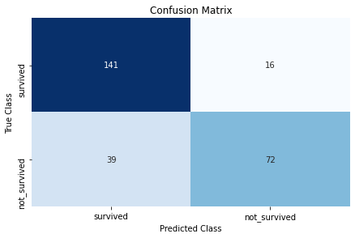

```python
# Criando a arvore de decisao
decision_tree = DecisionTreeClassifier(random_state=0)

# Treinando o modelo
modelo1 = decision_tree.fit(X_train, target_train)

# Verificando a acuracia do modelo
acuracia1 = accuracy_score(target_test, modelo1.predict(X_test))
print("A acuracia da Arvore de decisão é {:.2f}%".format(acuracia1*100))
print()

make_confusion_matrix(target_test, modelo1.predict(X_test))
```

### Random Forest

```
A acuracia da floresta de decisão é 81.34%
```

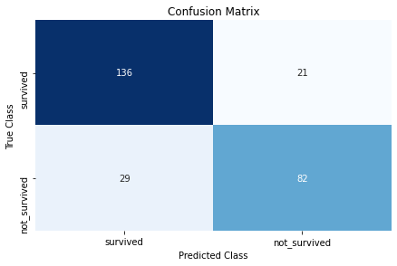

```python
random_forest = RandomForestClassifier(n_estimators = 100, max_depth=20, random_state=0)
modelo2 = random_forest.fit(X_train, target_train)

# Verificando a acuracia do modelo
acuracia2 = accuracy_score(target_test, modelo2.predict(X_test))
print("A acuracia da floresta de decisão é {:.2f}%".format(acuracia2*100))
print()

make_confusion_matrix(target_test, modelo2.predict(X_test))
```